# Avocado Price Data Visualization

B10401038

### Data Content

source:https://www.kaggle.com/neuromusic/avocado-prices

This data was downloaded from the [Hass Avocado Board website](http://www.hassavocadoboard.com) in May of 2018 & compiled into a single CSV.

The table below represents weekly 2018 retail scan data for National retail volume (units) and price. Retail scan data comes directly from retailers?? cash registers based on actual retail sales of Hass avocados. Starting in 2013, the table below reflects an expanded, multi-outlet retail data set. Multi-outlet reporting includes an aggregation of the following channels: grocery, mass, club, drug, dollar and military. The Average Price (of avocados) in the table reflects a per unit (per avocado) cost, even when multiple units (avocados) are sold in bags. The Product Lookup codes (PLU??s) in the table are only for Hass avocados. Other varieties of avocados (e.g. greenskins) are not included in this table.

##### Some relevant columns in the dataset

- Date - The date of the observation
- AveragePrice - the average price of a single avocado
- type - conventional or organic
- year - the year
- Region - the city or region of the observation
- Total Volume - Total number of avocados sold
- 4046 - Total number of avocados with PLU 4046 sold
- 4225 - Total number of avocados with PLU 4225 sold
- 4770 - Total number of avocados with PLU 4770 sold

[about PLU](http://indexfresh.com/retail-foodservice/brands/packaging/plus/)

> Data Analysis And Visualization

Do some element changes to organise materials in raw csv data

```r
library(ggplot2)
library(RColorBrewer)
avocado = read.csv("avocado.csv")

avocado$year<-as.factor(avocado$year)
avocado$Date<-as.Date(avocado$Date)
avocado<-avocado[order(avocado$Date),]

str(avocado)
```

```
## 'data.frame':    18249 obs. of  14 variables:
##  $ X           : int  51 51 51 51 51 51 51 51 51 51 ...
##  $ Date        : Date, format: "2015-01-04" "2015-01-04" ...
##  $ AveragePrice: num  1.22 1 1.08 1.01 1.02 1.4 0.93 1.19 1.11 0.88 ...
##  $ Total.Volume: num  40873 435021 788025 80034 491738 ...
##  $ X4046       : num  2820 364302 53987 44562 7194 ...
##  $ X4225       : num  28287 23821 552906 24964 396752 ...
##  $ X4770       : num  49.9 82.2 39995 2752.3 128.8 ...
##  $ Total.Bags  : num  9716 46816 141137 7756 87663 ...
##  $ Small.Bags  : num  9187 16707 137146 6064 87407 ...
##  $ Large.Bags  : num  530 30109 3991 1691 256 ...
##  $ XLarge.Bags : num  0 0 0 0 0 ...
##  $ type        : Factor w/ 2 levels "conventional",..: 1 1 1 1 1 1 1 1 1 1 ...
##  $ year        : Factor w/ 4 levels "2015","2016",..: 1 1 1 1 1 1 1 1 1 1 ...
##  $ region      : Factor w/ 54 levels "Albany","Atlanta",..: 1 2 3 4 5 6 7 8 9 10 ...
```

Compare the average price between two types of avocado in each year

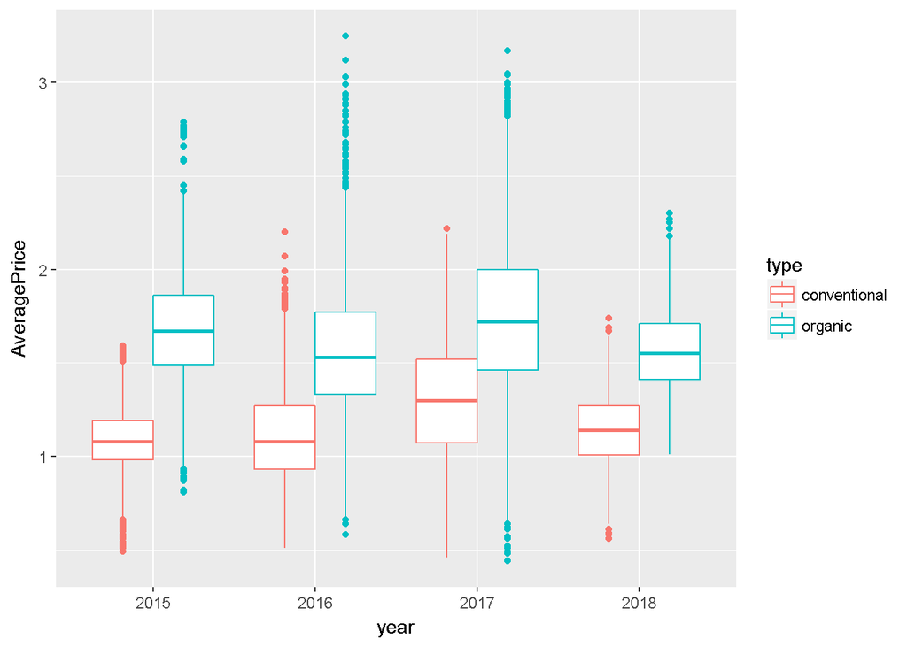

```r
ggplot(avocado, aes(year, AveragePrice,colour = type)) +
  geom_boxplot()
```

Trend chart of avocado price

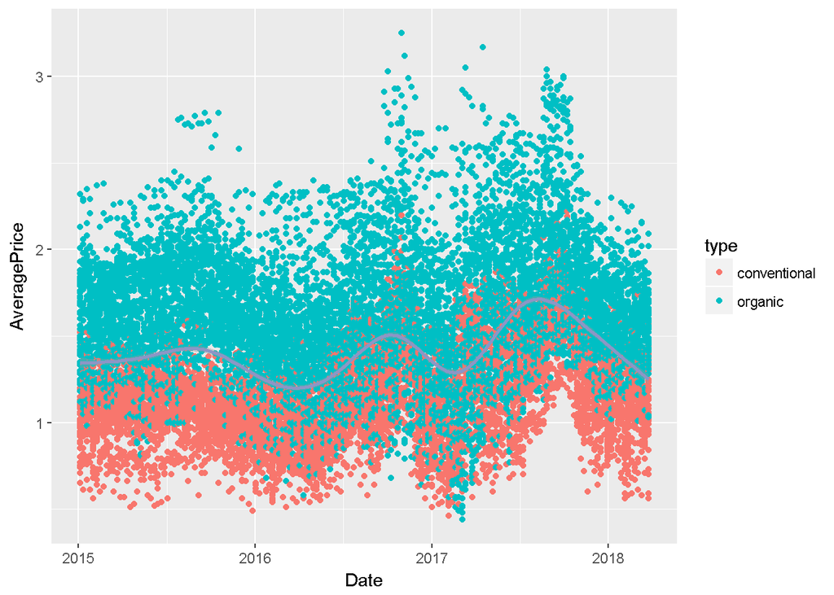

```r
ggplot(avocado, aes(Date, AveragePrice, colour = type)) +
  geom_point() +
  geom_smooth(color=brewer.pal(9, "BuPu")[5])
```

Distribution of average price and sales volume in three different PLU type

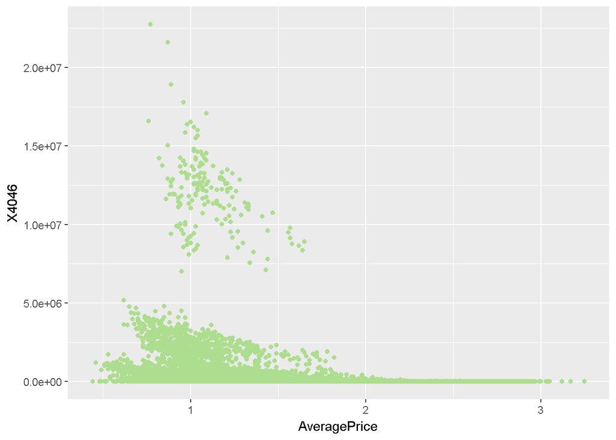

```r
ggplot(avocado, aes(AveragePrice, X4046)) +
  geom_point(color=brewer.pal(9, "YlGn")[4])
```

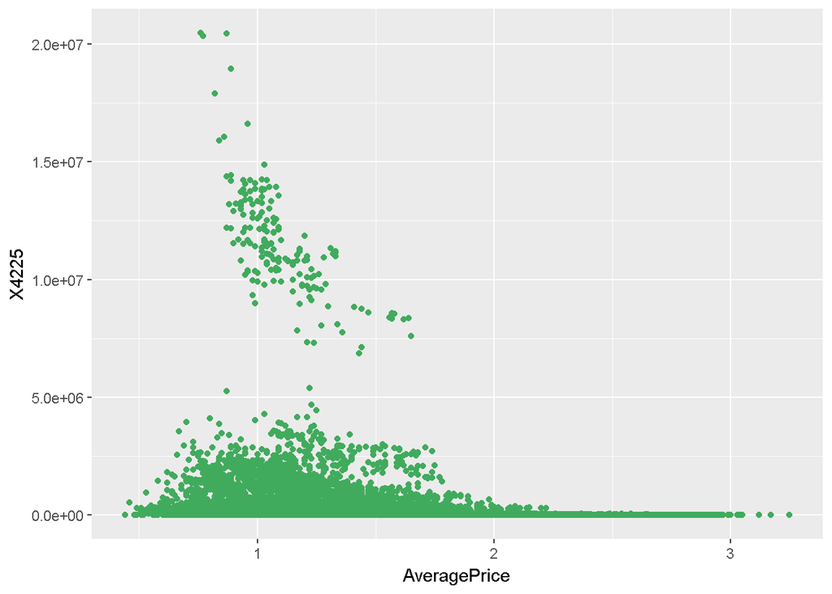

```r
ggplot(avocado, aes(AveragePrice, X4225)) +
  geom_point(color=brewer.pal(9, "YlGn")[6])
```

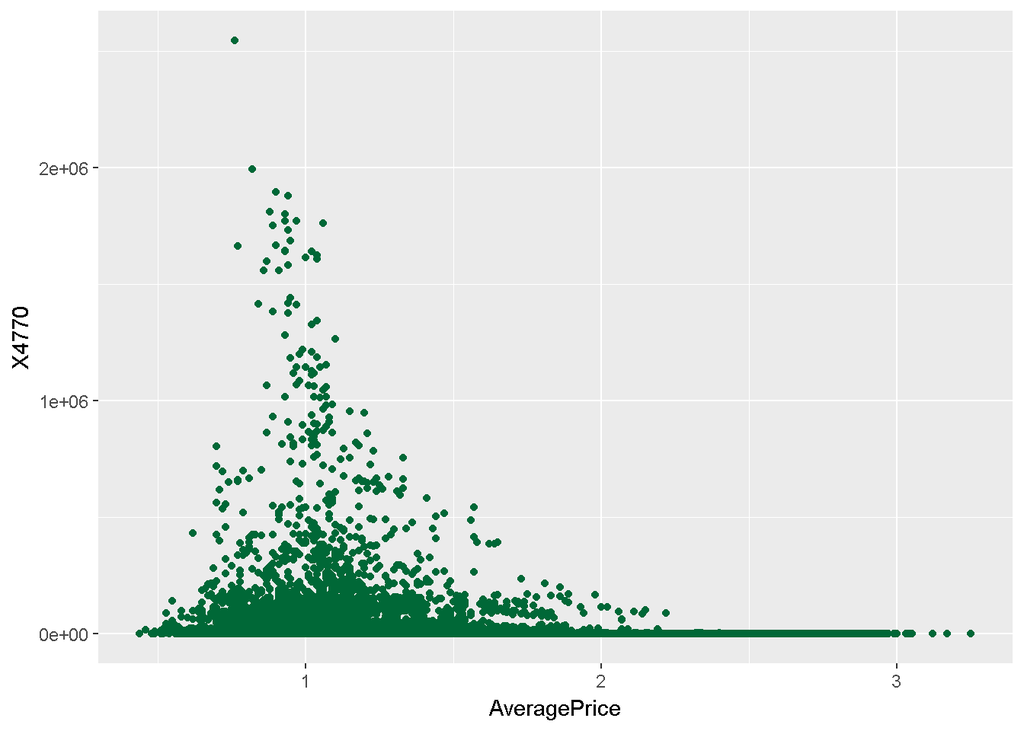

```r
ggplot(avocado, aes(AveragePrice, X4770)) +
  geom_point(color=brewer.pal(9, "YlGn")[8])
```